# Lab 5 Salamanders

Joshua Driscoll

10/13/2021

- Environmental Code

```r
library(here)
ricker_fun = function(x, a, b)
{
  return(a * x * exp(-b * x))
}

line_point_slope = function(x, x1, y1, slope)
  {
    get_y_intercept =
      function(x1, y1, slope)
        return(-(x1 * slope) + y1)

    linear =
      function(x, yint, slope)
        return(yint + x * slope)

    return(linear(x, get_y_intercept(x1, y1, slope), slope))
}

dispersal <- read.csv(here("data", "dispersal.csv"))
```

- Q1

```r
exp_fun = function(x, a, b)
{return(a*exp(-b * x))}
```

- Q2

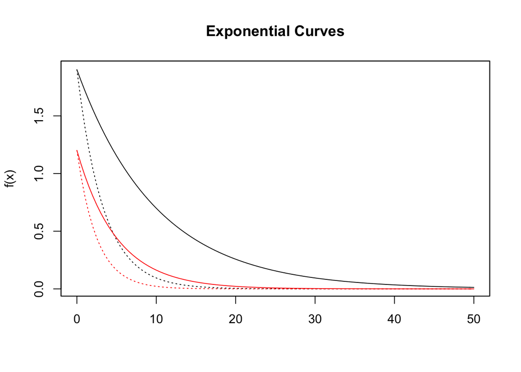

```r
curve(exp_fun(x, 1.9, .1), add = FALSE, from = 0, to = 50,
 ann = FALSE, axes = TRUE, ylab = "f(x)"); box()
curve(exp_fun(x, 1.9, .3), lty = "dotted", add = TRUE)
curve(exp_fun(x, 1.2, .2), col = "red", add = TRUE)
curve(exp_fun(x, 1.2, .4), col = "red", lty = "dotted", add = TRUE)
title(main = "Exponential Curves", ylab = "f(x)")
```

** **For some reason the title wouldn’t display when the main argument was within the first curve function so I improvised with title**

- Q3

When you change the a parameter, the graph has a lower y intercept and the position of the graph changes. When changing the a parameter by -.7 in this example, the graph shifts down the y axis. The a parameter alters the y intercept.

- Q4

When you change the b parameter, the slope of the graph changes. When changing the b parameter in this example, the slope gets steeper with higher values of b.

- Q5

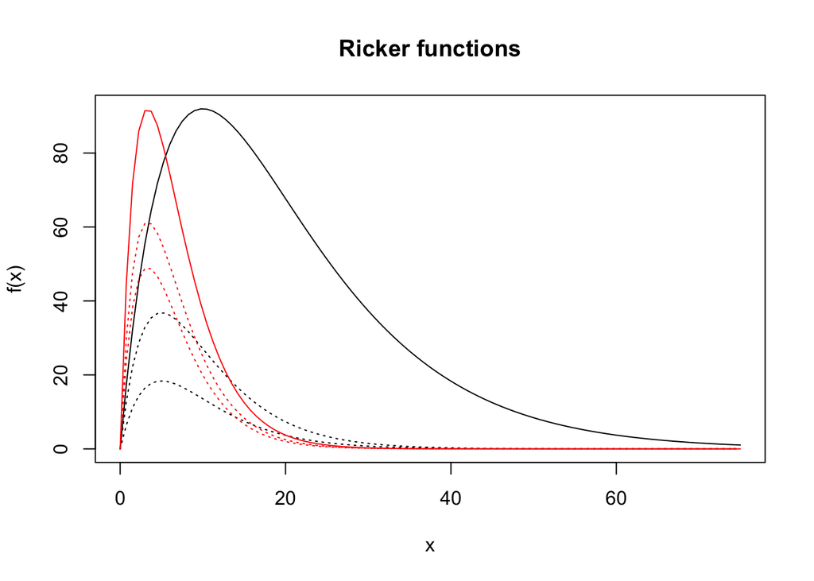

```r
curve(
  ricker_fun(x, 25, .1), add = FALSE, from = 0, to = 75,
  main = "Ricker functions",
  ylab = "f(x)", xlab = "x")
curve(
  ricker_fun(x, 20, .2), lty = "dotted", add = TRUE)
curve(
  ricker_fun(x, 10, .2), lty = "dotted", add = TRUE)
curve(
  ricker_fun(x, 75, .3), col = "red", add = TRUE)
curve(
  ricker_fun(x, 50, .3), col = "red", lty = "dotted", add = TRUE)
curve(
  ricker_fun(x, 40, .3), col = "red", lty = "dotted", add = TRUE)
```

- Q6

As you change the a parameter the initial slope of the graph changes. This causes the graph to get taller as the slope of the initial line increases.

- Q7

As you change the b parameter the height of the graph changes. This causes the graph to get shorter or taller depending on the value of b that is input.

- Q8

Slope: -.0004

X: 503

Y: .4

I chose the X and Y parameters by looking for a centralized point using the Locator(1) function. Once I had the X and Y of my point, I used trial and error to find the slope. I originally had dificulty as my slope was nowhere near small enough to look correct but then I looked at the scale of the X axis and figured it out.

- Q 9

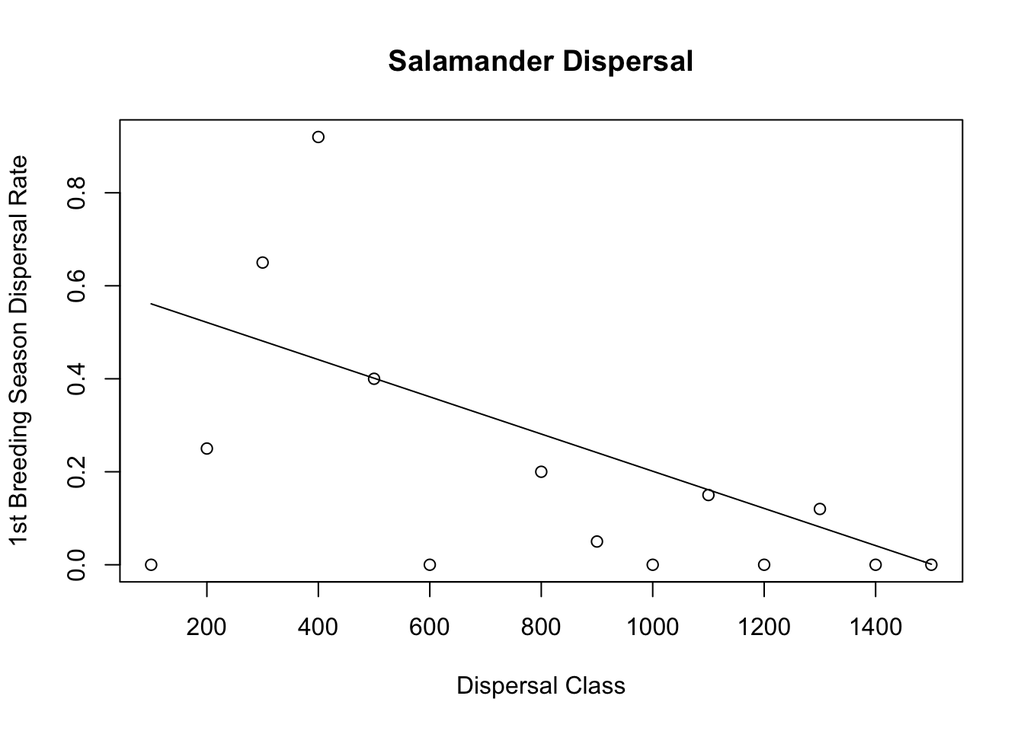

```r
plot(x = dispersal$dist.class, y = dispersal$disp.rate.ftb, main = "Salamander Dispersal", xlab = "Dispersal Class", ylab = "1st Breeding Season Dispersal Rate")
curve(line_point_slope(x, 503, .4, -.0004), add = TRUE)
```

- Q 10

a = 1.2

b = .003

- Q 11

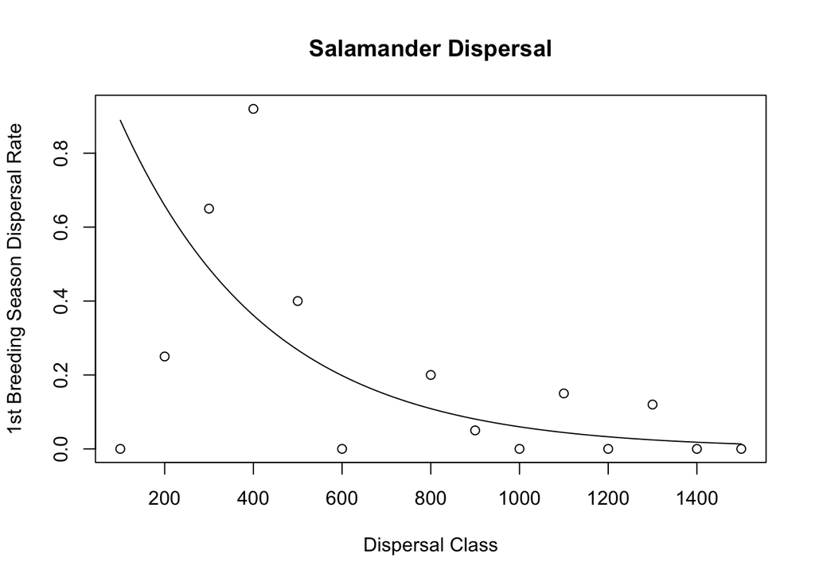

```r
plot(x = dispersal$dist.class, y = dispersal$disp.rate.ftb, main = "Salamander Dispersal", xlab = "Dispersal Class", ylab = "1st Breeding Season Dispersal Rate")
curve(exp_fun(x, 1.2, .003), add = TRUE)
```

- Q 12

a = .009

b = .004

I found these values by starting with my values for the exponential function and then using a lot of trial and error to find the correct values. While I understand what a and b change in the equation, it was difficult to translate that knowledge into a good guess for a and b in a real world scenario.

- Q 13

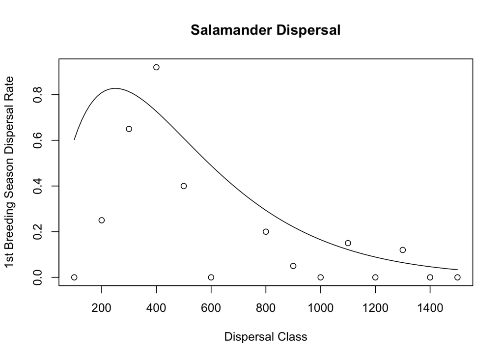

```r
plot(x = dispersal$dist.class, y = dispersal$disp.rate.ftb, main = "Salamander Dispersal", xlab = "Dispersal Class", ylab = "1st Breeding Season Dispersal Rate")
curve(ricker_fun(x, .009, .004), add = TRUE)
```

- Q 14

```r
linear_pred <- line_point_slope(dispersal$dist.class, 503, .4, -.0004)
resids_linear <- (dispersal$disp.rate.ftb) - linear_pred

exp_pred <- exp_fun(dispersal$dist.class, 1.2, .003)
resids_exp <- (dispersal$disp.rate.ftb) - exp_pred

rick_pred <- ricker_fun(dispersal$dist.class, .009, .004)
resids_ricker <- (dispersal$disp.rate.ftb) - rick_pred

data.frame(resids_linear, resids_exp, resids_ricker)
```

```
##    resids_linear  resids_exp resids_ricker
## 1        -0.5612 -0.88898186   -0.60328804
## 2        -0.2712 -0.40857396   -0.55879214
## 3         0.1688  0.16211641   -0.16322437
## 4         0.4788  0.55856695    0.19317254
## 5        -0.0012  0.13224381   -0.20900877
## 6        -0.3612 -0.19835867   -0.48987695
## 7             NA          NA            NA
## 8        -0.0812  0.09113846   -0.09348787
## 9        -0.1912 -0.03064662   -0.17132215
## 10       -0.2012 -0.05974448   -0.16484075
## 11       -0.0112  0.10574020    0.02845433
## 12       -0.1212 -0.03278847   -0.08888127
## 13        0.0388  0.09570971    0.05545620
## 14       -0.0412 -0.01799469   -0.04659308
## 15       -0.0012 -0.01333080   -0.03346315
```

- Q 15

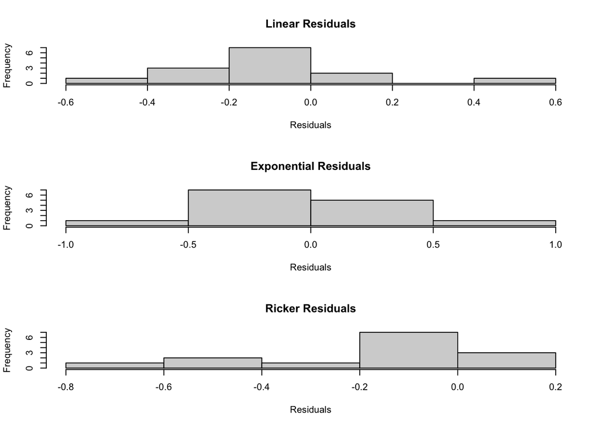

```r
par(mfrow = c(3, 1))
hist(resids_linear, main = "Linear Residuals", xlab = "Residuals")
hist(resids_exp, main = "Exponential Residuals", xlab = "Residuals")
hist(resids_ricker, main = "Ricker Residuals", xlab = "Residuals")
```